# QuantEcon.Notes test Notebook

This **notebook** tests the Jupyter rendering to help debug what is supported and what is not supported by QuantEcon Notes project.

```python
#Basic Code Block
import numpy as np
```

## Math

Jupyter Math Environments

$$ \mathbb P\{X^* \leq s\} \simeq \frac{1}{n} \sum_{t=1}^n \mathbb 1\{X_t \leq s\} $$

Jupyter Math Environment with NewLines

$$ \mathbb P\{X^* \leq s\} \simeq \frac{1}{n} \sum_{t=1}^n \mathbb 1\{X_t \leq s\} $$

Latex `\begin{equation}`

\begin{equation} \mathbb P\{X^* \leq s\} \simeq \frac{1}{n} \sum_{t=1}^n \mathbb 1\{X_t \leq s\} \end{equation}

LaTeX `\begin{equation*}`

\begin{equation*} \mathbb P\{X^* \leq s\} \simeq \frac{1}{n} \sum_{t=1}^n \mathbb 1\{X_t \leq s\} \end{equation*}

**InLine Equations**

Here is an inline equation: $ \mathbb P\{X^* \leq s\} \simeq \frac{1}{n} \sum_{t=1}^n \mathbb 1\{X_t \leq s\} $

**Aligned Equations**

LaTeX `\begin{aligned}` wrapped in `$$`

$$ \begin{aligned} z_{t+1} &= A z_t + C w_{t+1} \\ y_t &= U z_t \end{aligned} $$

LaTeX `\begin{aligned}`

\begin{aligned} z_{t+1} &= A z_t + C w_{t+1} \\ y_t &= U z_t \end{aligned}

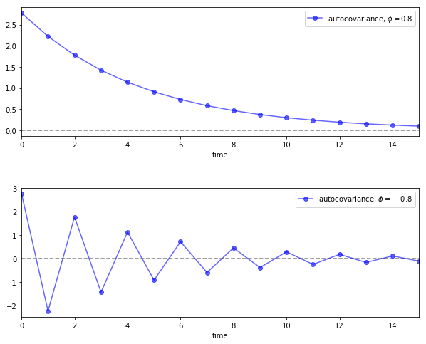

```python
# Code Block with Figure Output
import numpy as np
import matplotlib.pyplot as plt

num_rows, num_cols = 2, 1
fig, axes = plt.subplots(num_rows, num_cols, figsize=(10, 8))
plt.subplots_adjust(hspace=0.4)

for i, ϕ in enumerate((0.8, -0.8)):
    ax = axes[i]
    times = list(range(16))
    acov = [ϕ**k / (1 - ϕ**2) for k in times]
    ax.plot(times, acov, 'bo-', alpha=0.6, label=f'autocovariance, $\phi = {ϕ:.2}$')
    ax.legend(loc='upper right')
    ax.set(xlabel='time', xlim=(0, 15))
    ax.hlines(0, 0, 15, linestyle='--', alpha=0.5)
plt.show()
```

## Markdown Basics

You can make text *italic* or **bold**.

You can build nested itemized or enumerated lists:

- One
  - Sublist
    - This
- Sublist - That - The other thing
- Two

Now another list:

1. Here we go
   1. Sublist
   2. Sublist
2. There we go
3. Now this

Block Qoutes

[output not shown]

**Links** can be used using Markdown Links

[QuantEcon](https://quantecon.org)

and using raw **html**

[QuantEcon](https://quantecon.org)

**Embedded Code** using `three backticks`

```
if (i=0; i<n; i++) {
  printf("hello %d\n", i);
  x += 4;
}
```

## HTML Support

| Company | Contact | Country |
| --- | --- | --- |
| Alfreds Futterkiste | Maria Anders | Germany |
| Centro comercial Moctezuma | Francisco Chang | Mexico |
| Ernst Handel | Roland Mendel | Austria |
| Island Trading | Helen Bennett | UK |
| Laughing Bacchus Winecellars | Yoshi Tannamuri | Canada |
| Magazzini Alimentari Riuniti | Giovanni Rovelli | Italy |

## External Files Support

Displaying an **image** using Markdown

[figure not shown]

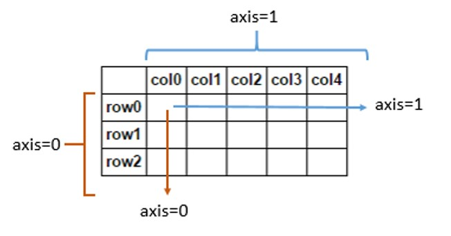

```python
from IPython.display import Image
Image('./dataframe.jpg')
```